# Analyzing WeRateDogs Tweets!

Do you know which is one of the funniest accounts on twitter? Obviously it has something to do with dogs! WeRateDogs is a Twitter account that rates people's dogs with a humorous comment about the dog. These ratings almost always have a denominator of 10. The numerators, though? Almost always greater than 10. 11/10, 12/10, 13/10, etc. Why? Because "they're good dogs Brent." WeRateDogs has over 8 million followers and has received international media coverage.

So let us dive in a bit deeper to understand this world of dogs and how they are always good. Let's see if we can find out answers to some quesitons such as which is the most liked tweet by users or which breeds names of dogs do people love the most and which breeds can a neural network identify with confidence? Sounds fun! Let's dig deeper.

### Tweet liked by most users

This doggo realized while swimming that he can stand in a pool! :D Looks definately Enlightened!! This tweet was liked by more than 156K people and has over 13M views!!!

```python
# Embed tweet in a jupyter notebook
class Tweet(object):
    def __init__(self, embed_str=None):
        self.embed_str = embed_str

    def _repr_html_(self):
        return self.embed_str

s = ("""
<blockquote class="twitter-tweet"><p lang="en" dir="ltr">Here&#39;s a doggo realizing you can stand in a pool. 13/10 enlightened af (vid by Tina Conrad) <a href="https://t.co/7wE9LTEXC4">pic.twitter.com/7wE9LTEXC4</a></p>&mdash; WeRateDogs® (@dog_rates) <a href="https://twitter.com/dog_rates/status/744234799360020481?ref_src=twsrc%5Etfw">June 18, 2016</a></blockquote> <script async src="https://platform.twitter.com/widgets.js" charset="utf-8"></script>
""")
Tweet(s)

# Source: https://github.com/jupyter/notebook/issues/2790
```

> Here's a doggo realizing you can stand in a pool. 13/10 enlightened af (vid by Tina Conrad) [pic.twitter.com/7wE9LTEXC4](https://t.co/7wE9LTEXC4)

> — WeRateDogs® (@dog_rates) [June 18, 2016](https://twitter.com/dog_rates/status/744234799360020481?ref_src=twsrc%5Etfw)

**Here is the doggo worthy of the most liked tweet!! 13/10**

### Most common breeds found by the neural network

WeRateDogs has over 5000+ tweets and amongst those, retrievers stood out to be the ones most commonly identified by a Neural Network. It seems that humans find retrievers as some of the most lovable and easy going doggos. They are certainly amongst the goodest of bois.

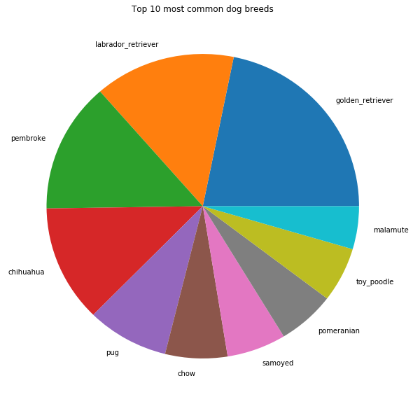

```python
# Display most common dog breeds via pie chart
master_df.first_prediction.value_counts().head(10).plot(kind = 'pie', figsize = (10, 10), title = 'Top 10 most common dog breeds', label = '');
```

The above pie-chart shows that **Retrievers** are the most common breeds found by the Neural Network

### Breeds for which the Neural Network is most and least confident in its prediction

There are certain types of breeds that stand out anywhere. And it turns out that some dogs can be identified more easily than others! Breeds such as Komondors look like a mop has come alive and hence very unique. :D

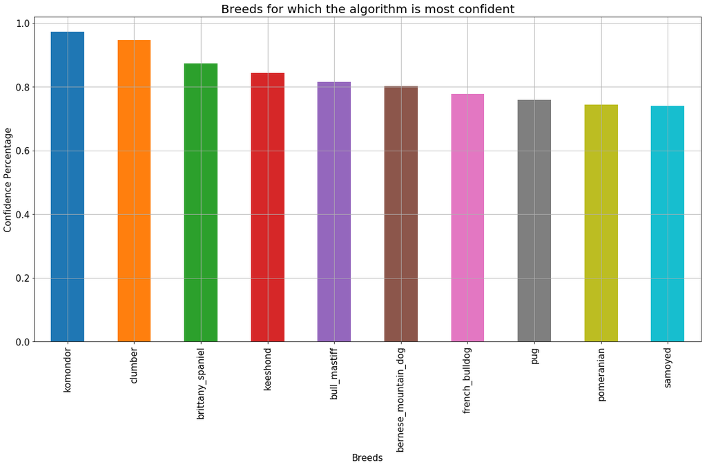

```python
true_df.groupby('first_prediction')['first_confidence'].mean().sort_values(ascending = False).head(10).plot(kind = 'bar', figsize = (20,10), grid = True, fontsize = 15);
plt.title('Breeds for which the algorithm is most confident', fontsize = 20)
plt.xlabel('Breeds', fontsize = 15)
plt.ylabel('Confidence Percentage', fontsize = 15);
```

**The komondor below certainly can be recognized very confidently due to its uniqueness!!!**

```python
# Assign jpg_url of komondor to a variable
komondor_url = master_df[master_df['first_prediction'] == 'komondor']['jpg_url'].values[0]

# Displays the breed for which the Neural Network is most confident!!!
Image(url = str(komondor_url))
```

[figure not shown]

### Breeds for which the Neural Network is least confident!

Well, for some breeds, it can be difficult for a Neural Network to recognize. It seems computers are still not at a place where they can achieve anything. :P Here are some of the least recognizable ones.

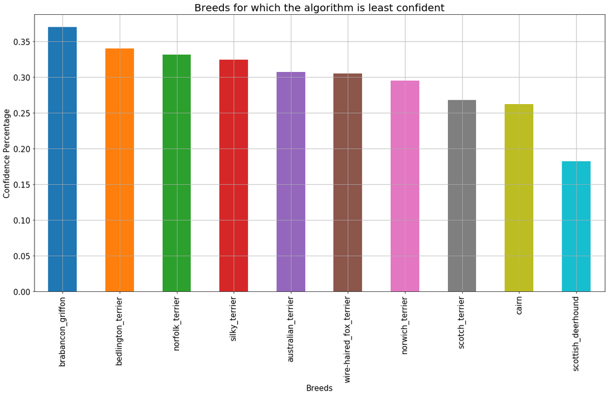

```python
true_df.groupby('first_prediction')['first_confidence'].mean().sort_values(ascending = False).tail(10).plot(kind = 'bar', figsize = (20,10), grid = True, fontsize = 15);
plt.title('Breeds for which the algorithm is least confident', fontsize = 20)
plt.xlabel('Breeds', fontsize = 15)
plt.ylabel('Confidence Percentage', fontsize = 15);
```

**Well, looking at the least recognized doggo, can't say I can blame the algorithm completely:P 13/10 for the Doggo though. He is a rebel. :D**

```python
# Assign jpg_url of scottish_deerhound to a variable
scottish_deerhound_url = master_df[master_df['first_prediction'] == 'scottish_deerhound']['jpg_url'].values[2]

# Displays the breed for which the Neural Network is least confident!!!
Image(url = str(scottish_deerhound_url))
```

[figure not shown]

### Most common names of dogs

Well.. Olivers, Coopers and Charlies of the doggo world are some of the most lovable names I could find. Anyways, what's there in a name. Dogs are always Good, Brent!!

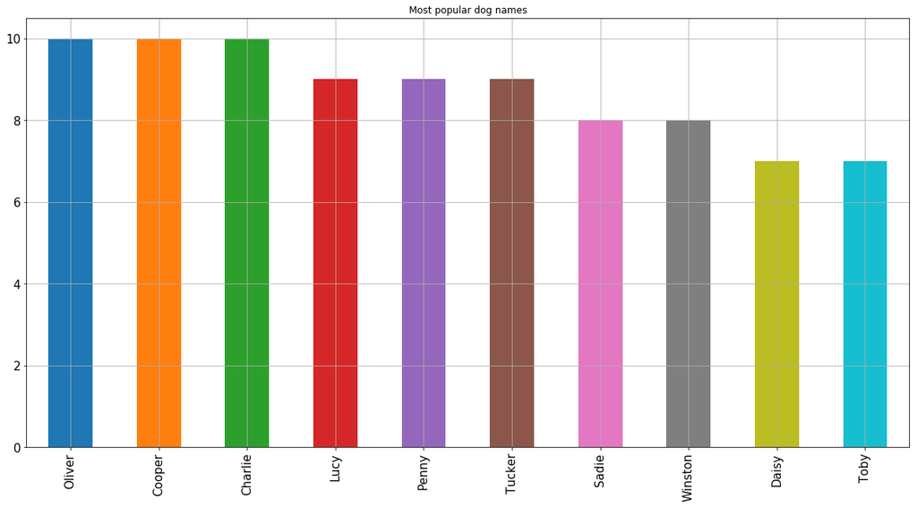

```python
# Displays bar chart with most common dog names
master_df.name.value_counts().head(10).plot(kind = 'bar', figsize = (20,10), grid = True, fontsize = 15, title = 'Most popular dog names').set_ylabel = ('# of dogs');
```

### Breeds that have the most number of retweets and likes

```python
# Select True dog breeds
true_breeds = master_df.query('first_dog == True')
```

```python
# Select necessary columns
most_fav_breeds = true_breeds[['favorites', 'retweets', 'first_prediction']]
```

```python
# Create dataframe grouped by first prediction
fav_breeds_df = pd.DataFrame(most_fav_breeds.groupby('first_prediction').sum())
```

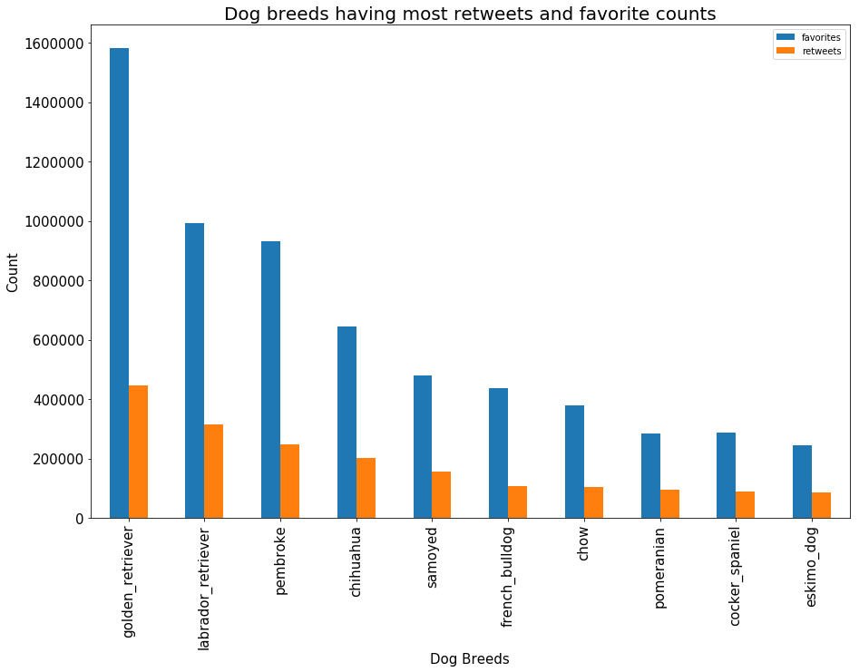

```python
# Plot bar chart for most number of retweets and favorites of Dog breeds
fav_breeds_df = fav_breeds_df.sort_values(by = 'retweets', ascending = False).head(10)
fav_breeds_df.plot(kind = 'bar', figsize = (15, 10), fontsize = 15)
plt.title('Dog breeds having most retweets and favorite counts', size = 20)
plt.xlabel('Dog Breeds', size = 15)
plt.ylabel('Count', size = 15);
```

**The retrievers win this one too. Probably because they are some of the most common, homely and goodest bois. :D**